# Assignment4-NeginBaghbanzadeh

## Assignment 4

This assignment asks you to use resources at hand to apply module 6 - Linear Regression to several sets of data.

## Learning Outcomes

- Exploratory analysis for regression
- Understand difference between linear and non-linear models
- Carry out OLS regression model
- Evaluate model

**Question 1**

- For each data set in Assignment4_linear_regression_data.xlsx:
- Create a scatter plot and visually decide if a linear model is appropriate (a matrix scatter plot will would be most efficient).
- If the relation is not linear, transform the data accordingly.
  - Try logarithm, exponential, square root, square, etc., for Y and/or X until you see a linear relation. You only need to report what is the transformation chosen, not all the attempts. Note: most of the time, you can guess visually. A systematic way is to create a matrix scatter plot of the different transformations. A generic way we did not cover is to use a Box-Cox transformation.
- Create an OLS model for the original and transformed data if required.
  - Evaluate if the OLS assumptions are met: normality of errors centered around zero, equal variance, etc..., for the original data and transformed data if appropriate.
  - Comment how the transformation impacted the different assumptions. (This should be done only by looking at the output diagnostic charts created by the software)
  - If datasets have outliers, remove the outliers and see the effect in the model (slope, intercept and R-square)

The output of the assignment should be:

- OLS full report for the original and transformed data if appropriate (only two datasets should need transformation).
- A short comment on the validity of the linear assumptions for the original and transformed data set when appropriate (it should not need to be longer than a couple of sentences).
- An interpretation of the slope and intercept in relation to the original data, i.e. if the model is linear [intercept value] is the expected value when the independent variable is zero, etc.). If the model is not linear, you need to transform the equation back to its original form.

Check out the following if you need further guidance: http://www.bzst.com/2009/09/interpreting-log-transformed-variables.html

https://stats.idre.ucla.edu/other/mult-pkg/faq/general/faqhow-do-i-interpret-a-regression-model-when-some-variables-are-log-transformed/

https://stats.idre.ucla.edu/sas/faq/how-can-i-interpret-log-transformed-variables-in-terms-of-percent-change-in-linear-regression/

https://stats.stackexchange.com/questions/266722/interpretation-of-linear-regression-results-where-dependent-variable-is-transfor

- If the dataset have outliers, determine if the outlier have leverage or not by comparing the OLS with and without the outlier.

```python
import pandas as pd
import openpyxl
import numpy as np
import seaborn as sns
import matplotlib.pyplot as plt
import copy
from scipy import stats
import statsmodels.api as sm
import statsmodels.formula.api as smf
import math

NUMBEROFSETS = 6
FILENAME = 'Assignment4_linear_regresion_data.xlsx'
Y = 0
X = 1
INTERCEPT = 0
SLOPE = 1
```

```python
dfs = []
for i in range(1, NUMBEROFSETS+1):
    dfs.append(pd.read_excel(FILENAME, sheet_name='Set '+str(i)))
```

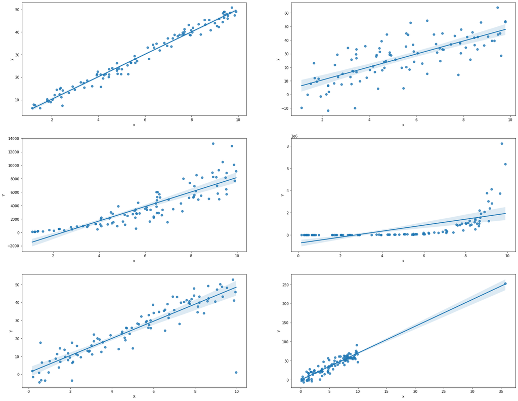

```python
figure, axis = plt.subplots(3, 2, figsize=(25, 20))

for i in range(0, 3):
    for j in range(0, 2):
        sns.regplot(y=dfs[2*i+j].columns[Y], x= dfs[2*i+j].columns[X], data=dfs[2*i+j], ax=axis[i, j])
plt.show()
```

All the data sets are linear except third and 4th data sets.

```python
linear_dfs = copy.deepcopy(dfs)
```

For the third plot we use Box-Cox transformation

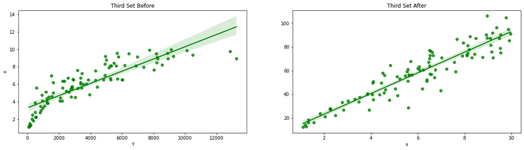

```python
figure, axis = plt.subplots(1, 2, figsize=(20, 5))
sns.regplot(y=dfs[2].columns[X], x= dfs[2].columns[Y], data=dfs[2], ax=axis[0], color='green')
axis[0].set_title("Third Set Before")
sns.regplot(x=dfs[2].columns[X], y=stats.boxcox(dfs[2][dfs[2].columns[Y]])[0], data=dfs[2],
            ax=axis[1], color='green')
axis[1].set_title("Third Set After")
```

```python
linear_dfs[2][linear_dfs[2].columns[Y]] = stats.boxcox(dfs[2][dfs[2].columns[Y]])[0]
```

The fourth plot is an exponentioal plot, so to transform it, we should apply log function on y.

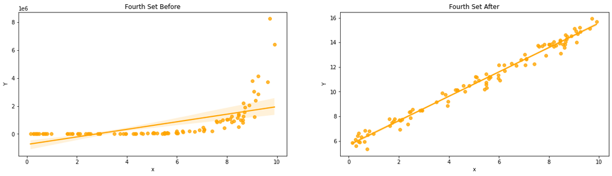

```python
figure, axis = plt.subplots(1, 2, figsize=(20, 5))
sns.regplot(y=dfs[3].columns[Y], x= dfs[3].columns[X], data=dfs[3], ax=axis[0], color='orange')
axis[0].set_title("Fourth Set Before")
sns.regplot(x=dfs[3].columns[X], y=np.log(dfs[3][dfs[3].columns[Y]]), data=dfs[3],
            ax=axis[1], color='orange')
axis[1].set_title("Fourth Set After")
```

```python
linear_dfs[3][linear_dfs[3].columns[Y]] = np.log(dfs[3][dfs[3].columns[Y]])
```

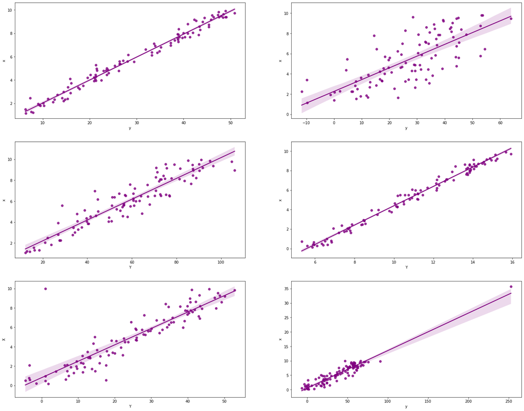

```python
figure, axis = plt.subplots(3, 2, figsize=(25, 20))

for i in range(0, 3):
    for j in range(0, 2):
        sns.regplot(y=linear_dfs[2*i+j].columns[X], x= linear_dfs[2*i+j].columns[Y],
                    data=linear_dfs[2*i+j], ax=axis[i, j], color='purple')
plt.show()
```

The following is the influence plot for the original data.

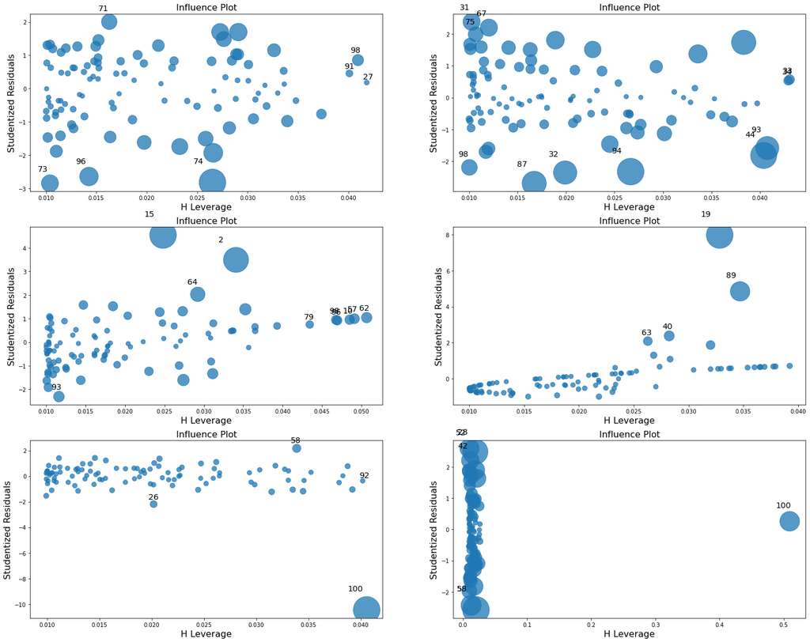

```python
ols_models = []
figure, axis = plt.subplots(3, 2, figsize=(25, 20))

for i in range(0, 3):
    for j in range(0, 2):
        results = smf.ols(dfs[2*i+j].columns[Y]+' ~ '+dfs[2*i+j].columns[X], data=dfs[2*i+j]).fit()
        ols_models.append(results)
        sm.graphics.influence_plot(results, ax=axis[i, j])

plt.show()
```

OLS model summary for original data

```python
for i in range(0, 6):
    print("-------------------------------   SET " + str(i+1) + "   ------------------------------------")
    print(ols_models[i].summary())
    print("\n\n")
```

```
-------------------------------   SET 1   ------------------------------------
                            OLS Regression Results
==============================================================================
Dep. Variable:                      y   R-squared:                       0.979
Model:                            OLS   Adj. R-squared:                  0.979
Method:                 Least Squares   F-statistic:                     4579.
Date:                Mon, 29 Nov 2021   Prob (F-statistic):           4.47e-84
Time:                        02:24:50   Log-Likelihood:                -206.03
No. Observations:                 100   AIC:                             416.1
Df Residuals:                      98   BIC:                             421.3
Df Model:                           1
Covariance Type:            nonrobust
==============================================================================
                 coef    std err          t      P>|t|      [0.025      0.975]
------------------------------------------------------------------------------
Intercept      0.2381      0.469      0.508      0.613      -0.693       1.169
x              4.9843      0.074     67.669      0.000       4.838       5.130
==============================================================================
Omnibus:                        4.971   Durbin-Watson:                   1.982
Prob(Omnibus):                  0.083   Jarque-Bera (JB):                4.783
Skew:                          -0.536   Prob(JB):                       0.0915
Kurtosis:                       2.988   Cond. No.                         15.9
==============================================================================

Notes:
[1] Standard Errors assume that the covariance matrix of the errors is correctly specified.



-------------------------------   SET 2   ------------------------------------
                            OLS Regression Results
==============================================================================
Dep. Variable:                      y   R-squared:                       0.555
Model:                            OLS   Adj. R-squared:                  0.551
Method:                 Least Squares   F-statistic:                     122.4
Date:                Mon, 29 Nov 2021   Prob (F-statistic):           6.11e-19
Time:                        02:24:50   Log-Likelihood:                -375.73
No. Observations:                 100   AIC:                             755.5
Df Residuals:                      98   BIC:                             760.7
Df Model:                           1
```

[output cut: 116 more lines]

```
Covariance Type:            nonrobust
==============================================================================
                 coef    std err          t      P>|t|      [0.025      0.975]
------------------------------------------------------------------------------
Intercept     -0.3059      1.534     -0.199      0.842      -3.350       2.739
x              7.0272      0.218     32.259      0.000       6.595       7.459
==============================================================================
Omnibus:                        0.494   Durbin-Watson:                   2.255
Prob(Omnibus):                  0.781   Jarque-Bera (JB):                0.262
Skew:                           0.120   Prob(JB):                        0.877
Kurtosis:                       3.070   Cond. No.                         11.8
==============================================================================

Notes:
[1] Standard Errors assume that the covariance matrix of the errors is correctly specified.
```

influence plot and summary for transformed data.

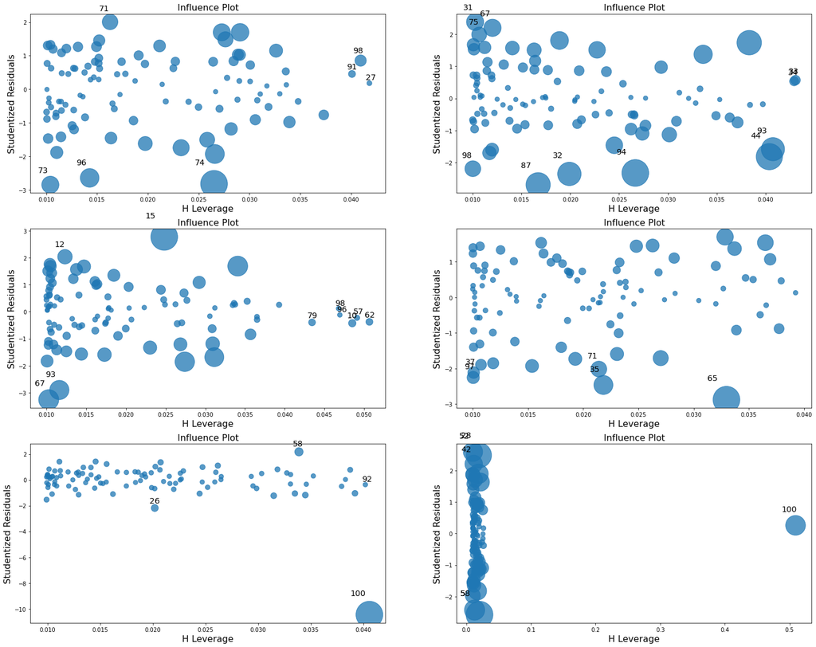

```python
ols_models_linear = []
figure, axis = plt.subplots(3, 2, figsize=(25, 20))

for i in range(0, 3):
    for j in range(0, 2):
        results = smf.ols(linear_dfs[2*i+j].columns[Y]+' ~ '+linear_dfs[2*i+j].columns[X],
                          data=linear_dfs[2*i+j]).fit()
        ols_models_linear.append(results)
        sm.graphics.influence_plot(results, ax=axis[i, j])

plt.show()
```

```python
for i in range(0, 6):
    print("-------------------------------   SET " + str(i+1) + "   ------------------------------------")
    print(ols_models_linear[i].summary())
    print("\n\n")
```

```
-------------------------------   SET 1   ------------------------------------
                            OLS Regression Results
==============================================================================
Dep. Variable:                      y   R-squared:                       0.979
Model:                            OLS   Adj. R-squared:                  0.979
Method:                 Least Squares   F-statistic:                     4579.
Date:                Mon, 29 Nov 2021   Prob (F-statistic):           4.47e-84
Time:                        02:24:51   Log-Likelihood:                -206.03
No. Observations:                 100   AIC:                             416.1
Df Residuals:                      98   BIC:                             421.3
Df Model:                           1
Covariance Type:            nonrobust
==============================================================================
                 coef    std err          t      P>|t|      [0.025      0.975]
------------------------------------------------------------------------------
Intercept      0.2381      0.469      0.508      0.613      -0.693       1.169
x              4.9843      0.074     67.669      0.000       4.838       5.130
==============================================================================
Omnibus:                        4.971   Durbin-Watson:                   1.982
Prob(Omnibus):                  0.083   Jarque-Bera (JB):                4.783
Skew:                          -0.536   Prob(JB):                       0.0915
Kurtosis:                       2.988   Cond. No.                         15.9
==============================================================================

Notes:
[1] Standard Errors assume that the covariance matrix of the errors is correctly specified.



-------------------------------   SET 2   ------------------------------------
                            OLS Regression Results
==============================================================================
Dep. Variable:                      y   R-squared:                       0.555
Model:                            OLS   Adj. R-squared:                  0.551
Method:                 Least Squares   F-statistic:                     122.4
Date:                Mon, 29 Nov 2021   Prob (F-statistic):           6.11e-19
Time:                        02:24:51   Log-Likelihood:                -375.73
No. Observations:                 100   AIC:                             755.5
Df Residuals:                      98   BIC:                             760.7
Df Model:                           1
```

[output cut: 116 more lines]

```
Covariance Type:            nonrobust
==============================================================================
                 coef    std err          t      P>|t|      [0.025      0.975]
------------------------------------------------------------------------------
Intercept     -0.3059      1.534     -0.199      0.842      -3.350       2.739
x              7.0272      0.218     32.259      0.000       6.595       7.459
==============================================================================
Omnibus:                        0.494   Durbin-Watson:                   2.255
Prob(Omnibus):                  0.781   Jarque-Bera (JB):                0.262
Skew:                           0.120   Prob(JB):                        0.877
Kurtosis:                       3.070   Cond. No.                         11.8
==============================================================================

Notes:
[1] Standard Errors assume that the covariance matrix of the errors is correctly specified.
```

```python
linear_coefs = [4.9843, 4.7774, 8.7229, 0.9898, 4.7671, 7.0272]
linear_stderrs = [0.074, 0.432, 0.344, 0.013, 0.235, 0.218]
```

```python
outliners_linear = [[27, 71, 73, 74, 91, 96, 98], [31, 32, 33, 34, 44, 67, 75, 87, 93, 94, 98],
             [10, 12, 57, 62, 67, 79, 93, 96, 98], [35, 37, 65, 71, 97], [26, 58, 92, 100], [42, 58, 100]]

without_outliners_linear = copy.deepcopy(linear_dfs)
for i in range(0, 6):
    without_outliners_linear[i] = without_outliners_linear[i].drop(outliners_linear[i])
```

```python
without_outliners_ols_models_linear = []
for i in range(0, 6):
    results = smf.ols(without_outliners_linear[i].columns[Y]+' ~ '+without_outliners_linear[i].columns[X],
                      data=without_outliners_linear[i]).fit()
    without_outliners_ols_models_linear.append(results)
```

```python
for i in range(0, 6):
    print("-------------------------------   SET " + str(i+1) + "   ------------------------------------")
    print(without_outliners_ols_models_linear[i].summary())
    print("\n\n")
```

```
-------------------------------   SET 1   ------------------------------------
                            OLS Regression Results
==============================================================================
Dep. Variable:                      y   R-squared:                       0.982
Model:                            OLS   Adj. R-squared:                  0.982
Method:                 Least Squares   F-statistic:                     5017.
Date:                Mon, 29 Nov 2021   Prob (F-statistic):           2.17e-81
Time:                        02:24:52   Log-Likelihood:                -180.30
No. Observations:                  93   AIC:                             364.6
Df Residuals:                      91   BIC:                             369.7
Df Model:                           1
Covariance Type:            nonrobust
==============================================================================
                 coef    std err          t      P>|t|      [0.025      0.975]
------------------------------------------------------------------------------
Intercept      0.5841      0.454      1.287      0.201      -0.318       1.486
x              4.9422      0.070     70.830      0.000       4.804       5.081
==============================================================================
Omnibus:                        7.468   Durbin-Watson:                   2.019
Prob(Omnibus):                  0.024   Jarque-Bera (JB):                3.483
Skew:                          -0.207   Prob(JB):                        0.175
Kurtosis:                       2.147   Cond. No.                         17.1
==============================================================================

Notes:
[1] Standard Errors assume that the covariance matrix of the errors is correctly specified.



-------------------------------   SET 2   ------------------------------------
                            OLS Regression Results
==============================================================================
Dep. Variable:                      y   R-squared:                       0.621
Model:                            OLS   Adj. R-squared:                  0.616
Method:                 Least Squares   F-statistic:                     142.3
Date:                Mon, 29 Nov 2021   Prob (F-statistic):           5.29e-20
Time:                        02:24:52   Log-Likelihood:                -314.70
No. Observations:                  89   AIC:                             633.4
Df Residuals:                      87   BIC:                             638.4
Df Model:                           1
```

[output cut: 116 more lines]

```
Covariance Type:            nonrobust
==============================================================================
                 coef    std err          t      P>|t|      [0.025      0.975]
------------------------------------------------------------------------------
Intercept      0.0984      1.835      0.054      0.957      -3.544       3.741
x              6.9521      0.298     23.291      0.000       6.360       7.545
==============================================================================
Omnibus:                        0.764   Durbin-Watson:                   2.186
Prob(Omnibus):                  0.682   Jarque-Bera (JB):                0.523
Skew:                           0.177   Prob(JB):                        0.770
Kurtosis:                       3.053   Cond. No.                         12.7
==============================================================================

Notes:
[1] Standard Errors assume that the covariance matrix of the errors is correctly specified.
```

```python
removed_coefs = [4.9422, 4.5221, 8.6391, 0.9851, 5.1356, 6.9521]
removed_stderrs = [0.070, 0.379, 0.366, 0.012, 0.154, 0.298]
```

```python
for i in range(0, 6):
    SE = math.sqrt((removed_stderrs[i])**2 + (linear_stderrs[i]**2))
    coef_diff = removed_coefs[i] - linear_coefs[i]
    p_value =  (1 - stats.norm.cdf(coef_diff/SE)) * 2
    print(p_value)
```

```
1.320614361582404
1.3431323136751678
1.1325016669801928
1.2094987022288204
0.1896706582323473
1.1611763032220639
```